# test1_olina

You can use book, google for examples, etc. Please use dplyr and ggplot as appropriate to explore, obtain results, and present findings.

```r
library(ggplot2)
library(nycflights13)
library(lubridate)
library(dplyr)
df <- flights
```

```r
flights
```

```
## # A tibble: 336,776 x 19
##     year month   day dep_time sched_dep_time dep_delay arr_time
##    <int> <int> <int>    <int>          <int>     <dbl>    <int>
##  1  2013     1     1      517            515         2      830
##  2  2013     1     1      533            529         4      850
##  3  2013     1     1      542            540         2      923
##  4  2013     1     1      544            545        -1     1004
##  5  2013     1     1      554            600        -6      812
##  6  2013     1     1      554            558        -4      740
##  7  2013     1     1      555            600        -5      913
##  8  2013     1     1      557            600        -3      709
##  9  2013     1     1      557            600        -3      838
## 10  2013     1     1      558            600        -2      753
## # ... with 336,766 more rows, and 12 more variables: sched_arr_time <int>,
## #   arr_delay <dbl>, carrier <chr>, flight <int>, tailnum <chr>,
## #   origin <chr>, dest <chr>, air_time <dbl>, distance <dbl>, hour <dbl>,
## #   minute <dbl>, time_hour <dttm>
```

## Task 1

Imagine you are choosing a ticket to fly *from* JFK. You want to know which day of the week (Mon, Tue, …) has lowest delays, and which one largest. How big is the difference? Is it big enough to make you choose one day vs another?

**Hint** use lubridate package. Google “lubridate vignette”. Many packages in R have these “vignettes” showing examples and explaining how to use a package. You will have to combine columns. There is a function which will provide you with the weekday number, given the columns with date. Be careful in interpreting a returned result.

```r
flights_delay_by_day <- group_by(flights, wday(time_hour, label = TRUE))
summarise(flights_delay_by_day,
          dep_delay_mean = mean(dep_delay, na.rm = TRUE),
          arr_delay_mean = mean(arr_delay, na.rm = TRUE)) %>%
arrange(dep_delay_mean)
```

```
## # A tibble: 7 x 3
##   `wday(time_hour, label = TRUE)` dep_delay_mean arr_delay_mean
##                             <ord>          <dbl>          <dbl>
## 1                             Sat       7.650502      -1.448828
## 2                            Tues      10.631683       5.388526
## 3                             Sun      11.589532       4.820024
## 4                             Wed      11.803512       7.051119
## 5                             Fri      14.696057       9.070120
## 6                             Mon      14.778937       9.653739
## 7                           Thurs      16.148920      11.740819
```

By calculating the departure and arrival delays, we can see that on average, Saturdays have lowest delays and Thursdays have highest delays.

### Comment

- Good
- (-1) You did include flights originated from other airports as well
- graph could help. Point, or boxplot, or both.
- how big is standart deviation and standart error for that matter for these means?
- how big is the difference in mean delays between delays?
- may be median is a better way (comparing ot mean) to describe this?
- the units of delay are not clear. Mention them when you interpret the results
- next you could do parametric or non-parametric ANOVA, if you know it
- Please, use notebook instead of Rmd files

## Taks 2

Now choose a particular destination, what can you say now?

```r
(flights_delay_by_day_IAH <- filter(flights, dest == "IAH") %>%
  group_by(wday(time_hour, label = TRUE))%>%
  summarise(dep_delay_mean = mean(dep_delay, na.rm = TRUE),
          arr_delay_mean = mean(arr_delay, na.rm = TRUE))%>%
   arrange(dep_delay_mean)
   )
```

```
## # A tibble: 7 x 3
##   `wday(time_hour, label = TRUE)` dep_delay_mean arr_delay_mean
##                             <ord>          <dbl>          <dbl>
## 1                            Tues       7.096805      0.4048964
## 2                             Sat       8.831325     -0.8226779
## 3                             Wed       8.954674      3.9536424
## 4                             Sun      10.357649      2.0203252
## 5                             Fri      12.500000      5.7485714
## 6                             Mon      13.037665      8.0000000
## 7                           Thurs      14.712512      9.2197697
```

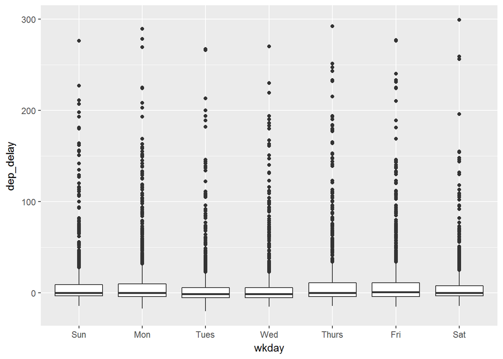

```r
flights_delay_IAH <- filter(flights, dest == "IAH") %>%
    mutate(wkday = wday(time_hour, label = TRUE))

flights_delay_IAH_ <- filter(flights, dest == "IAH") %>%
    mutate(wkday = wday(time_hour, label = TRUE))%>%
    filter(dep_delay<300)

  ggplot(data = flights_delay_IAH_) +
  geom_boxplot(mapping = aes(x = wkday,y = dep_delay))
```

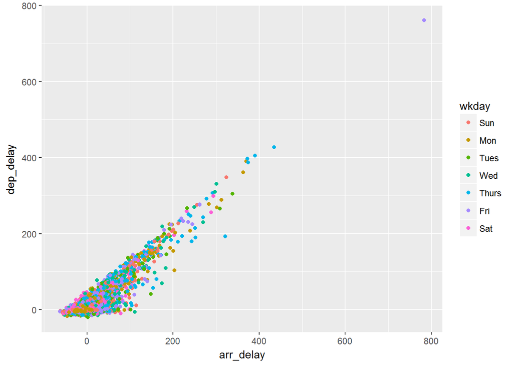

```r
  ggplot(data = flights_delay_IAH) +
  geom_point(mapping = aes(x = arr_delay,y = dep_delay,color = wkday))
```

This is for the destination IAH (George Bush Intercontinental Airport). The table shows that the delay situation is similar to the general data. The delays are lowest on Tuesdays and Saturdays, highest on Mondays and Thursdays. In general, the average delay is little lower than average for all airports. The boxplot and dotplot shows that there’s no significant difference between the days.The medians are similar.

### Comment

- good
- after you did graph, analyze it. For example
  - on the last plot (which you do not discuss at all) there are some dots, where dep_delay is 0, but arrival delay ~100. What does it represent?
  - what this last plot shows you? correlation between dep_delay and arr_delay? What do you see? May be smooth line would help here?
  - acctually, very itneresting plot by itself…

## Taks 3

Now for a chosen destination, choose a best carrier-weekday combination. Compare it to the worst one.

```r
flights_delay_IAH
```

```
## # A tibble: 7,198 x 20
##     year month   day dep_time sched_dep_time dep_delay arr_time
##    <int> <int> <int>    <int>          <int>     <dbl>    <int>
##  1  2013     1     1      517            515         2      830
##  2  2013     1     1      533            529         4      850
##  3  2013     1     1      623            627        -4      933
##  4  2013     1     1      728            732        -4     1041
##  5  2013     1     1      739            739         0     1104
##  6  2013     1     1      908            908         0     1228
##  7  2013     1     1     1028           1026         2     1350
##  8  2013     1     1     1044           1045        -1     1352
##  9  2013     1     1     1114            900       134     1447
## 10  2013     1     1     1205           1200         5     1503
## # ... with 7,188 more rows, and 13 more variables: sched_arr_time <int>,
## #   arr_delay <dbl>, carrier <chr>, flight <int>, tailnum <chr>,
## #   origin <chr>, dest <chr>, air_time <dbl>, distance <dbl>, hour <dbl>,
## #   minute <dbl>, time_hour <dttm>, wkday <ord>
```

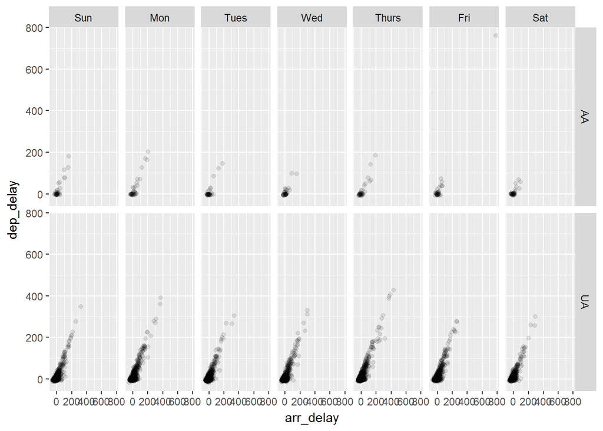

```r
ggplot(data = flights_delay_IAH) +
  geom_point(mapping = aes(x = arr_delay,y = dep_delay),alpha = 1/10) +
  facet_grid(carrier~wkday)
```

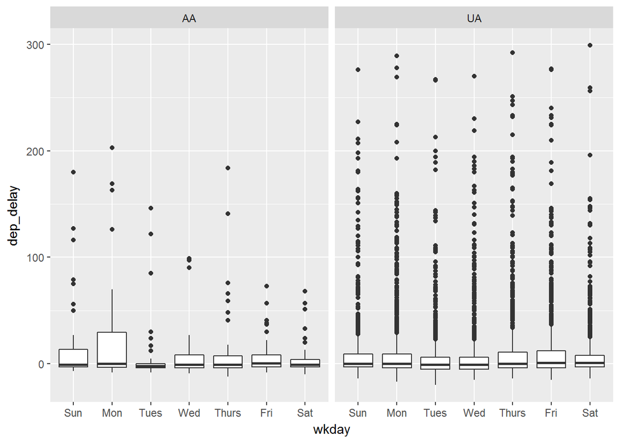

```r
ggplot(data = flights_delay_IAH_) +
  geom_boxplot(mapping = aes(x=wkday, y = dep_delay)) +
  facet_wrap(~carrier)
```

### Comment

- Very good

## Task 4

For the chosen best carrier-destination combination compare delays at a regular day vs one of the national holidays.

```r
(flights_delay_by_day_IAH_AA <-
   filter(flights_delay_IAH,wkday == "Sat") %>%
    mutate(d_d = lubridate::date(time_hour)))
```

```
## # A tibble: 845 x 21
##     year month   day dep_time sched_dep_time dep_delay arr_time
##    <int> <int> <int>    <int>          <int>     <dbl>    <int>
##  1  2013     1     5      516            515         1      821
##  2  2013     1     5      534            530         4      829
##  3  2013     1     5      746            746         0     1101
##  4  2013     1     5      757            730        27     1119
##  5  2013     1     5      851            858        -7     1248
##  6  2013     1     5     1017           1015         2     1351
##  7  2013     1     5     1043           1043         0     1416
##  8  2013     1     5     1200           1200         0     1517
##  9  2013     1     5     1406           1359         7     1715
## 10  2013     1     5     1410           1410         0     1732
## # ... with 835 more rows, and 14 more variables: sched_arr_time <int>,
## #   arr_delay <dbl>, carrier <chr>, flight <int>, tailnum <chr>,
## #   origin <chr>, dest <chr>, air_time <dbl>, distance <dbl>, hour <dbl>,
## #   minute <dbl>, time_hour <dttm>, wkday <ord>, d_d <date>
```

```r
(flights_delay_by_day_IAH_AA_date <-
  filter(flights_delay_by_day_IAH_AA, d_d == "2014-12-25"))
```

```
## # A tibble: 0 x 21
## # ... with 21 variables: year <int>, month <int>, day <int>,
## #   dep_time <int>, sched_dep_time <int>, dep_delay <dbl>, arr_time <int>,
## #   sched_arr_time <int>, arr_delay <dbl>, carrier <chr>, flight <int>,
## #   tailnum <chr>, origin <chr>, dest <chr>, air_time <dbl>,
## #   distance <dbl>, hour <dbl>, minute <dbl>, time_hour <dttm>,
## #   wkday <ord>, d_d <date>
```

Haven’t find a holiday with flights yet…

### Comment

- Please use select to keep only those columns you need. This way when you print df you would see the structure of columns.
- look at range(flights_delay_by_day_IAH_AA$d_d) - there is no “2014-12-25” for this one.
- (-1) flights_delay_by_day_IAH_AA contains only Saturdays. Are you sure 2014-12-25 is Saturday? The following code would find some flights in range for you  
  flights_delay_IAH %>% mutate(d_d = lubridate::date(time_hour)) %>% filter(d_d == “2013-07-04”)